# Lubridate: Theory and Practice

# Overview

- Lubridate is a R package that belongs to the tidyverse and makes working with dates and times easier and more intuitive
- Base R functions for dates and times are unintuitive and limited such as `as.POSIXct()`, `ISOdate()` or `as.POSIXct.Date()`
- Lubridate
  - Offers consistent and easy to handle functions, that take special features as leap years, leap seconds, daylight savings time (DST) or time zones into account
  - Overrides base R functions for working with dates and times
  - Focuses on working with dates and datetimes, not times in particular (for that see hms package)
  - Refers to a specific moment in time as an **instant**
- A [Cheat Sheet](https://rawgit.com/rstudio/cheatsheets/master/lubridate.pdf) with the most important formulas and explanations is available

# Prerequisites

- Lubridate is not part of the core tidyverse and thus needs an extra installation via `install.packages("lubridate")`
- When working with lubridate installing and using the tidyverse is recommended:

```r
library(lubridate)
library(tidyverse)
```

- The Development version of the package is available on GitHub (other packages needed to install)

## Preparing the Data

- Load and inspect the data, check for NAs and remove empty columns

```r
df <- read_csv("police_project.csv")
View(df)

df %>%
  count(is.na(county_name))
```

```
# A tibble: 1 x 2
  `is.na(county_name)`     n
  <lgl>                <int>
1 TRUE                 91741
```

```r
df %>%
  count(is.na(search_type))
```

```
# A tibble: 2 x 2
  `is.na(search_type)`     n
  <lgl>                <int>
1 FALSE                 3196
2 TRUE                 88545
```

```r
df <- df %>%
  within(rm(county_name))
```

- Set theme for visualizations to classic

```r
theme_set(theme_classic())
```

# Creating Dates and Datetimes

- Three types refer to an instant
  - Date `<date>`
    - If displayed in numeric context (e.g. histogram) 1 means one day
  - Time `<time>`
  - Datetime `<dttm>`
    - If displayed in numeric context (e.g. histogram) 1 means one second
- Always use *simplest* possible type (no unnecessary datetime)
- Get current date or datetime via `today()` and `now()` functions

## Create Dates and Datetimes from String

- Functions automatically work out format if order of **y**ear, **m**onth, **d**ay, **h**our, **m**inute and **s**econd is specified
  - Automatically recognize common separators **“-”**, **“/”**, **“.”** and **" "**

```r
mdy_hm("January, 31st, 2019 10:45")
```

```
[1] "2019-01-31 10:45:00 UTC"
```

## Create Dates and Datetimes from Individual Components/Columns

- For making dates use `make_date()`
- For making datetimes use `make_datetime()`

```r
# New column with format datetime
df <- df %>%
  mutate(stop_date_time=make_datetime(year=year(stop_date), month = month(stop_date), day =
         day(stop_date), hour = hour(stop_time), min = minute(stop_time), sec = second(stop_time)))
```

- In this case very long, instead the functions from the chapter before can be used

```r
df <- df %>%
  mutate(stop_date_time=ymd_hms(paste(stop_date,stop_time)))
```

## Create Dates and Datetimes from Other Types

- For switching between date and datetime or when working with numeric offsets from unix systems use `as_date()` or `as_datetime()`

# Components of Dates and Datetimes

## Getting Components

- Use accessor functions to get specific components of dates or datetimes, similar to functions creating dates and datetimes, such as `year()`, `month()`, `yday()`, `mday()`, `wday()`, `hour()`, `minute()`, `second()`
  - For `month()` and `wday()` set **label = T** to display the name and set **abbr = F** to display the full name, otherwise the abbrevation will be shown

```r
# Show all speeding drivers under 25 while grouping by year component of stop_date_time
df %>%
  group_by(year(stop_date_time)) %>%
  filter(violation=="Speeding" & driver_age < 25) %>%
  count()
```

```
# A tibble: 11 x 2
# Groups:   year(stop_date_time) [11]
   `year(stop_date_time)`     n
                    <dbl> <int>
 1                   2005   628
 2                   2006  2542
 3                   2007  2254
 4                   2008  1747
 5                   2009  1246
 6                   2010  1234
 7                   2011  1130
 8                   2012  1310
 9                   2013   995
10                   2014  1127
11                   2015  1122
```

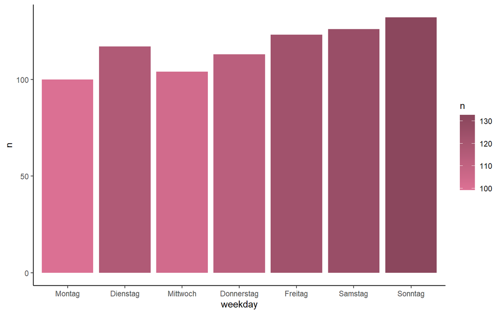

```r
# Show the overall number of drunk drivers sorted by weekday component of stop_date_time
df %>%
  filter(drugs_related_stop == T) %>%
  group_by(weekday=wday(stop_date_time, label = T, abbr = F, week_start = 1)) %>%
  count() %>%
  ggplot(aes(x = weekday, y = n)) +
  geom_bar(stat = "identity", aes(fill = n)) +
  scale_fill_gradient(low = "palevioletred", high = "palevioletred4")
```

## Setting Components

- To set a component of a single date or datetime to a specific value use the same functions as for getting components, e.g. `year()`, `month()`, `hour()` etc.
- To set multiple values at once use `update()`, where all date components for a certain variable or column can be specified at once
- If a set value is too big, it will automatically roll over to the next bigger unit, e.g. adding 30 days to Feb. 1st will result in a date or datetime with month march

## Rounding Components

- Rounding dates is useful when dealing with units that are not a direct component of a date or datetime, such as quarters or weeks
- Three functions to round
  - `floor_date()` rounds to the next smaller unit
  - `round_date()` rounds to mathematically nearest unit
  - `ceiling_date()` rounds to next bigger unit

```r
# New columns for rounded quarters
df <- df %>%
    mutate(Quarter = as_date(round_date(x = stop_date_time, unit = "quarter")),
           Floor_Quarter = as_date(floor_date(stop_date_time, "quarter")),
           Ceiling_Quarter = as_date(ceiling_date(stop_date_time, "quarter")))
df[1,] %>% select(stop_date_time, Quarter, Floor_Quarter, Ceiling_Quarter)
```

```
# A tibble: 1 x 4
  stop_date_time      Quarter    Floor_Quarter Ceiling_Quarter
  <dttm>              <date>     <date>        <date>
1 2005-01-02 01:55:00 2005-01-01 2005-01-01    2005-04-01
```

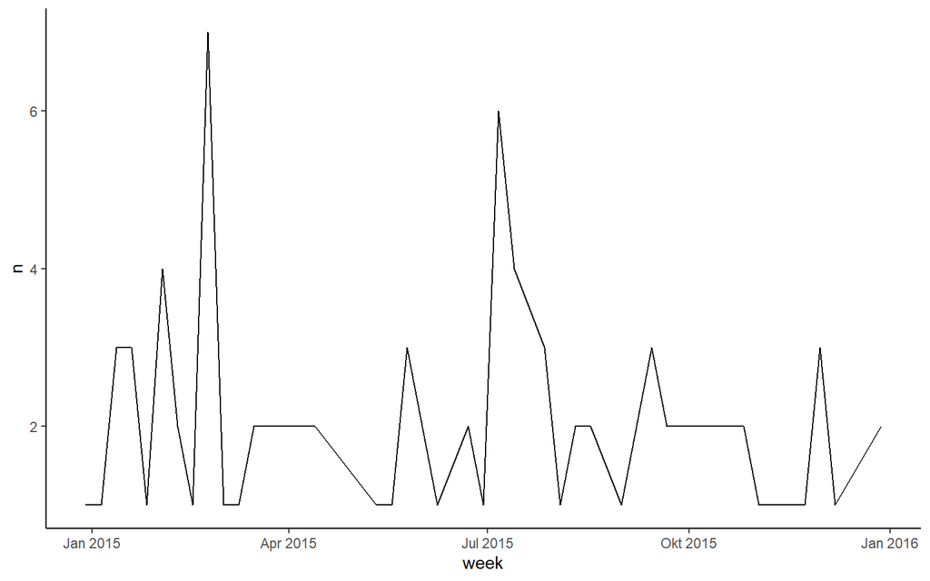

```r
# Show the number of drug related stops in 2015 per week
df %>%
  filter(year(stop_date_time)==2015, drugs_related_stop == T) %>%
  count(week = floor_date(stop_date_time, "week", week_start = 1)) %>%
  ggplot(aes(x = week, y = n)) +
  geom_line()
```

# Time Spans

- Three classes of time spans in R

## Duration

- Durations represent the exact **number of seconds** between two instants (fixed length)
- All difftime objects can be formatted into a duration to get a fixed result unit (seconds) with `as.duration()`

```r
# Calculating the time difference between two stops
df <- df %>%
  mutate(time_diff = stop_date_time - lag(stop_date_time),
         duration = as.duration(time_diff))
df %>% select(stop_date_time, duration)
```

```
# A tibble: 91,741 x 2
   stop_date_time      duration
   <dttm>              <Duration>
 1 2005-01-02 01:55:00 NA
 2 2005-01-18 08:15:00 1405200s (~2.32 weeks)
 3 2005-01-23 23:15:00 486000s (~5.62 days)
 4 2005-02-20 17:15:00 2397600s (~3.96 weeks)
 5 2005-03-14 10:00:00 1874700s (~3.1 weeks)
 6 2005-03-23 09:45:00 776700s (~1.28 weeks)
 7 2005-04-01 17:30:00 805500s (~1.33 weeks)
 8 2005-06-06 13:20:00 5687400s (~9.4 weeks)
 9 2005-07-13 10:15:00 3185700s (~5.27 weeks)
10 2005-07-13 15:45:00 19800s (~5.5 hours)
# ... with 91,731 more rows
```

- Calculating with durations works with similar functions as before, e.g. `dyears()` or `dhours()`

```r
# Calculate limitation date
df <- df %>%
  mutate(limitation = as_date(stop_date_time + dyears(3)))
df %>% select(stop_date_time, limitation)
```

```
# A tibble: 91,741 x 2
   stop_date_time      limitation
   <dttm>              <date>
 1 2005-01-02 01:55:00 2008-01-02
 2 2005-01-18 08:15:00 2008-01-18
 3 2005-01-23 23:15:00 2008-01-23
 4 2005-02-20 17:15:00 2008-02-20
 5 2005-03-14 10:00:00 2008-03-13
 6 2005-03-23 09:45:00 2008-03-22
 7 2005-04-01 17:30:00 2008-03-31
 8 2005-06-06 13:20:00 2008-06-05
 9 2005-07-13 10:15:00 2008-07-12
10 2005-07-13 15:45:00 2008-07-12
# ... with 91,731 more rows
```

**ATTENTION**

- No `dmonth()` function as months don’t have the same length
- When confronted with higher units than seconds the conversion rate is 60 seconds a minute, 60 minutes an hour etc. and thus specalities such as DST aren’t considered

## Period

- Periods don’t have the same length, but work in human units such as days, months etc.
- They are more intuitive to work with than durations
- Takes specialities such as DST or leap years into account
- All difftime objects can be formatted into a period with `as.period()`

```r
# Calculating the time difference between two stops as a period
df <- df %>%
  mutate(period = as.period(time_diff))
df %>% select(stop_date_time, duration, period)
```

```
# A tibble: 91,741 x 3
   stop_date_time      duration               period
   <dttm>              <Duration>             <Period>
 1 2005-01-02 01:55:00 NA                     NA
 2 2005-01-18 08:15:00 1405200s (~2.32 weeks) 16d 6H 20M 0S
 3 2005-01-23 23:15:00 486000s (~5.62 days)   5d 15H 0M 0S
 4 2005-02-20 17:15:00 2397600s (~3.96 weeks) 27d 18H 0M 0S
 5 2005-03-14 10:00:00 1874700s (~3.1 weeks)  21d 16H 45M 0S
 6 2005-03-23 09:45:00 776700s (~1.28 weeks)  8d 23H 45M 0S
 7 2005-04-01 17:30:00 805500s (~1.33 weeks)  9d 7H 45M 0S
 8 2005-06-06 13:20:00 5687400s (~9.4 weeks)  65d 19H 50M 0S
 9 2005-07-13 10:15:00 3185700s (~5.27 weeks) 36d 20H 55M 0S
10 2005-07-13 15:45:00 19800s (~5.5 hours)    5H 30M 0S
# ... with 91,731 more rows
```

- Creating and calculating with periods works with similar functions as before, e.g. `years()`, `months()`, `hours()` etc.

```r
# Calculate limitation date with period
df <- df %>%
  mutate(limitation_period = as_date(stop_date_time + years(3)))
df %>% select(stop_date_time, limitation, limitation_period)
```

```
# A tibble: 91,741 x 3
   stop_date_time      limitation limitation_period
   <dttm>              <date>     <date>
 1 2005-01-02 01:55:00 2008-01-02 2008-01-02
 2 2005-01-18 08:15:00 2008-01-18 2008-01-18
 3 2005-01-23 23:15:00 2008-01-23 2008-01-23
 4 2005-02-20 17:15:00 2008-02-20 2008-02-20
 5 2005-03-14 10:00:00 2008-03-13 2008-03-14
 6 2005-03-23 09:45:00 2008-03-22 2008-03-23
 7 2005-04-01 17:30:00 2008-03-31 2008-04-01
 8 2005-06-06 13:20:00 2008-06-05 2008-06-06
 9 2005-07-13 10:15:00 2008-07-12 2008-07-13
10 2005-07-13 15:45:00 2008-07-12 2008-07-13
# ... with 91,731 more rows
```

**ATTENTION**

- `hour()` != `hours()`, `month()` != `months()` etc.

## Interval

- Intervals represent a duration with a specific starting point (and ending point)
- Accurate measurement of time spans (periods and durations lack context often)
- Not useful for datetime calculations as intervals are bound to a start and an end
  - If intervals are added to datetime objects R coerces it into a duration
- When building an interval the date that occurs earlier in time must be called first, so that the length is always positive

```r
df <- df %>% mutate(interval = lag(stop_date_time) %--% stop_date_time)
df %>% select(stop_date_time, interval)
```

```
# A tibble: 91,741 x 2
   stop_date_time      interval
   <dttm>              <Interval>
 1 2005-01-02 01:55:00 NA--NA
 2 2005-01-18 08:15:00 2005-01-02 01:55:00 UTC--2005-01-18 08:15:00 UTC
 3 2005-01-23 23:15:00 2005-01-18 08:15:00 UTC--2005-01-23 23:15:00 UTC
 4 2005-02-20 17:15:00 2005-01-23 23:15:00 UTC--2005-02-20 17:15:00 UTC
 5 2005-03-14 10:00:00 2005-02-20 17:15:00 UTC--2005-03-14 10:00:00 UTC
 6 2005-03-23 09:45:00 2005-03-14 10:00:00 UTC--2005-03-23 09:45:00 UTC
 7 2005-04-01 17:30:00 2005-03-23 09:45:00 UTC--2005-04-01 17:30:00 UTC
 8 2005-06-06 13:20:00 2005-04-01 17:30:00 UTC--2005-06-06 13:20:00 UTC
 9 2005-07-13 10:15:00 2005-06-06 13:20:00 UTC--2005-07-13 10:15:00 UTC
10 2005-07-13 15:45:00 2005-07-13 10:15:00 UTC--2005-07-13 15:45:00 UTC
# ... with 91,731 more rows
```

```r
# Or use

df <- df %>%
  mutate(interval = interval(start = lag(stop_date_time), end = stop_date_time))
```

- Calculate the periods in an interval with integer division `%/%` (division without remainers)

```r
df <- df %>%
  mutate(interval_days = interval %/% days(1))
df %>% select(stop_date_time, interval_days)
```

```
# A tibble: 91,741 x 2
   stop_date_time      interval_days
   <dttm>                      <dbl>
 1 2005-01-02 01:55:00            NA
 2 2005-01-18 08:15:00            16
 3 2005-01-23 23:15:00             5
 4 2005-02-20 17:15:00            27
 5 2005-03-14 10:00:00            21
 6 2005-03-23 09:45:00             8
 7 2005-04-01 17:30:00             9
 8 2005-06-06 13:20:00            65
 9 2005-07-13 10:15:00            36
10 2005-07-13 15:45:00             0
# ... with 91,731 more rows
```

## What Time Span to Use

- Always use simplest possible data structure
  - Use **duration** if you only care for physical time
  - Use **period** if you need to work with human units
  - Use **interval** if you need to know how long a time span is in human units

# Time Zones

- Time zones are complicated to work with, because of geopolitical entities or ambiguous everyday names, such as Eastern Standard Time, which is different in the USA, Canada or Australia
- Time Zone is an attribute of the datetime object
- R uses international standard time zones displayed in `<continent>/<city>`
- If no time zone is specified R assumes UTC, which doesn’t use DST
- Operations that combine dates or datetimes (e.g. `c()`) often drop assigned time zones and use the local time zone
- Local time zone can be displayed via `Sys.timezone()`
- Complete list of time zones can be displayed via `OlsonNames()`
- Change time zone on two levels
  - Keep the instant and only change how it’s displayed `with_tz()`
  - Change the underlying instant, e.g. when wrong time zone is assigned `force_tz()`

```r
# Keep instant
df <- df %>%
  mutate(displayed_tz = with_tz(time = stop_date_time, tzone = "America/New_York"))
# Change instant
df <- df %>%
  mutate(changed_tz = force_tz(time = stop_date_time, tzone = "America/New_York"))
df %>% select(stop_date_time, displayed_tz, changed_tz)
```

```
# A tibble: 91,741 x 3
   stop_date_time      displayed_tz        changed_tz
   <dttm>              <dttm>              <dttm>
 1 2005-01-02 01:55:00 2005-01-01 20:55:00 2005-01-02 01:55:00
 2 2005-01-18 08:15:00 2005-01-18 03:15:00 2005-01-18 08:15:00
 3 2005-01-23 23:15:00 2005-01-23 18:15:00 2005-01-23 23:15:00
 4 2005-02-20 17:15:00 2005-02-20 12:15:00 2005-02-20 17:15:00
 5 2005-03-14 10:00:00 2005-03-14 05:00:00 2005-03-14 10:00:00
 6 2005-03-23 09:45:00 2005-03-23 04:45:00 2005-03-23 09:45:00
 7 2005-04-01 17:30:00 2005-04-01 12:30:00 2005-04-01 17:30:00
 8 2005-06-06 13:20:00 2005-06-06 09:20:00 2005-06-06 13:20:00
 9 2005-07-13 10:15:00 2005-07-13 06:15:00 2005-07-13 10:15:00
10 2005-07-13 15:45:00 2005-07-13 11:45:00 2005-07-13 15:45:00
# ... with 91,731 more rows
```

# Sources

1. https://www.kaggle.com/faressayah/stanford-open-policing-project
2. https://openpolicing.stanford.edu/
3. https://rawgit.com/rstudio/cheatsheets/master/lubridate.pdf
4. https://r4ds.had.co.nz/dates-and-times.html
5. https://www.rdocumentation.org/packages/lubridate/versions/1.7.4/topics/interval
6. https://lubridate.tidyverse.org/reference/round_date.html
7. https://lubridate.tidyverse.org/
8. https://www.jstatsoft.org/article/view/v040i03

Laura Noetzel

2019-10-29